# More Text Mining

M Loecher

## tf-idf

One approach of weighting is to look at a term’s *inverse document frequency* (idf), which decreases the weight for commonly used words and increases the weight for words that are not used very much in a collection of documents. This can be combined with term frequency to calculate a term’s *tf-idf* (the two quantities multiplied together), the frequency of a term adjusted for how rarely it is used.

The statistic **tf-idf** is intended to measure how important a word is to a document in a collection (or corpus) of documents, for example, to one novel in a collection of novels or to one website in a collection of websites.

It is a rule-of-thumb or heuristic quantity; while it has proved useful in text mining, search engines, etc., its theoretical foundations are considered less than firm by information theory experts. The inverse document frequency for any given term is defined as

$$idf(\text{term}) = \ln{\left(\frac{n_{\text{documents}}}{n_{\text{documents containing term}}}\right)}$$

### A corpus of physics texts

Let’s work with another corpus of documents, to see what terms are important in a different set of works. In fact, let’s leave the world of fiction and narrative entirely. Let’s download some classic physics texts from Project Gutenberg and see what terms are important in these works, as measured by tf-idf. Let’s download [*Discourse on Floating Bodies* by Galileo Galilei](http://www.gutenberg.org/ebooks/37729), [*Treatise on Light* by Christiaan Huygens](http://www.gutenberg.org/ebooks/14725), [*Experiments with Alternate Currents of High Potential and High Frequency* by Nikola Tesla](http://www.gutenberg.org/ebooks/13476), and [*Relativity: The Special and General Theory* by Albert Einstein](http://www.gutenberg.org/ebooks/5001).

```r
library(gutenbergr)
physics <- gutenberg_download(c(37729, 14725, 13476, 5001),
                              meta_fields = "author")
save(physics, file="data/physics.rda")
```

```r
physics_words <- physics %>%
  unnest_tokens(word, text) %>%
  count(author, word, sort = TRUE) %>%
  ungroup()

physics_words
```

```
## # A tibble: 12,592 x 3
##    author              word      n
##    <chr>               <chr> <int>
##  1 Galilei, Galileo    the    3760
##  2 Tesla, Nikola       the    3604
##  3 Huygens, Christiaan the    3553
##  4 Einstein, Albert    the    2994
##  5 Galilei, Galileo    of     2049
##  6 Einstein, Albert    of     2030
##  7 Tesla, Nikola       of     1737
##  8 Huygens, Christiaan of     1708
##  9 Huygens, Christiaan to     1207
## 10 Tesla, Nikola       a      1176
## # ... with 12,582 more rows
```

Here we see just the raw counts; we need to remember that these documents are all different lengths. Let’s go ahead and calculate tf-idf, then visualize the high tf-id words in Figure @ref(fig:plotphysics).

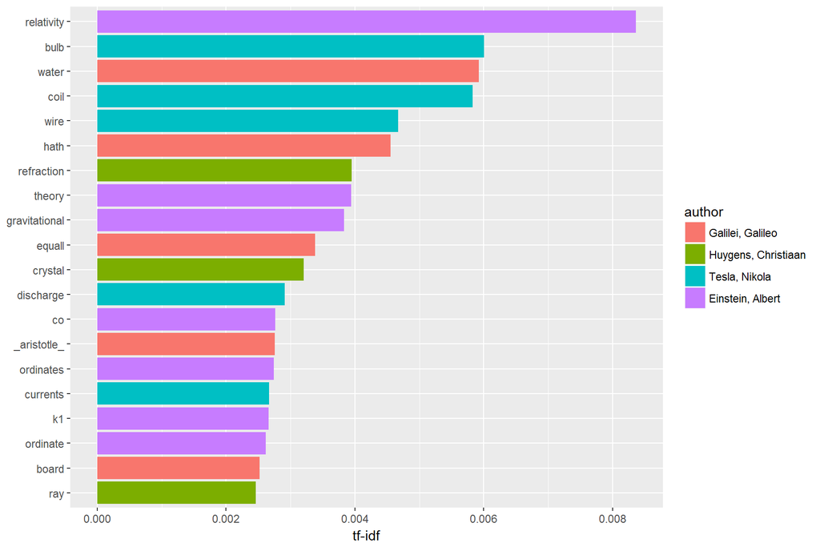

Highest tf-idf words in classic physics corpus

```r
physics_words <- physics_words %>%
  bind_tf_idf(word, author, n)

plot_physics <- physics_words %>%
  arrange(desc(tf_idf)) %>%
  mutate(word = factor(word, levels = rev(unique(word)))) %>%
  mutate(author = factor(author, levels = c("Galilei, Galileo",
                                            "Huygens, Christiaan",
                                            "Tesla, Nikola",
                                            "Einstein, Albert")))

ggplot(plot_physics[1:20,], aes(word, tf_idf, fill = author)) +
  geom_col() +
  labs(x = NULL, y = "tf-idf") +
  coord_flip()
```

## n-grams

We want to tokenize into consecutive sequences of words, called n-grams. By seeing how often word X is followed by word Y, we can then build a model of the relationships between them.

We do this by adding the `token = "ngrams"` option to `unnest_tokens()`, and setting `n` to the number of words we wish to capture in each n-gram. When we set `n` to 2, we are examining pairs of two consecutive words, often called “bigrams”:

```r
physics_bigrams <- physics %>%
  unnest_tokens(bigram, text, token = "ngrams", n = 2)

physics_bigrams
```

```
## # A tibble: 149,801 x 3
##    gutenberg_id author           bigram
##           <int> <chr>            <chr>
##  1         5001 Einstein, Albert albert einstein
##  2         5001 Einstein, Albert einstein reference
##  3         5001 Einstein, Albert reference archive
##  4         5001 Einstein, Albert archive relativity
##  5         5001 Einstein, Albert relativity the
##  6         5001 Einstein, Albert the special
##  7         5001 Einstein, Albert special and
##  8         5001 Einstein, Albert and general
##  9         5001 Einstein, Albert general theory
## 10         5001 Einstein, Albert theory by
## # ... with 149,791 more rows
```

This data structure is still a variation of the tidy text format. It is structured as one-token-per-row (with extra metadata, such as `book`, still preserved), but each token now represents a bigram.

### Counting and filtering n-grams

Our usual tidy tools apply equally well to n-gram analysis. We can examine the most common bigrams using dplyr’s `count()`:

```r
physics_bigrams %>%
  count(bigram, sort = TRUE)
```

```
## # A tibble: 59,856 x 2
##    bigram        n
##    <chr>     <int>
##  1 of the     2785
##  2 to the     1174
##  3 in the      985
##  4 that the    555
##  5 the water   505
##  6 it is       503
##  7 the same    473
##  8 and the     389
##  9 from the    348
## 10 to be       335
## # ... with 59,846 more rows
```

As one might expect, a lot of the most common bigrams are pairs of common (uninteresting) words, such as `of the` and `to be`: what we call “stop-words”. This is a useful time to use tidyr’s `separate()`, which splits a column into multiple based on a delimiter. This lets us separate it into two columns, “word1” and “word2”, at which point we can remove cases where either is a stop-word.

```r
#library(tidyr)

bigrams_separated <- physics_bigrams %>%
  separate(bigram, c("word1", "word2"), sep = " ")

bigrams_filtered <- bigrams_separated %>%
  filter(!word1 %in% stop_words$word) %>%
  filter(!word2 %in% stop_words$word)

# new bigram counts:
bigram_counts <- bigrams_filtered %>%
  count(word1, word2, sort = TRUE)

bigram_counts
```

```
## # A tibble: 9,667 x 3
##    word1         word2       n
##    <chr>         <chr>   <int>
##  1 straight      line      115
##  2 gravitational field      60
##  3 reference     body       56
##  4 straight      lines      49
##  5 absolute      gravity    43
##  6 ordinate      system     39
##  7 3             2          36
##  8 special       theory     36
##  9 cone          _a         35
## 10 illustration  fig        33
## # ... with 9,657 more rows
```

These most common pairs make more sense for physics books.

In other analyses, we may want to work with the recombined words. tidyr’s `unite()` function is the inverse of `separate()`, and lets us recombine the columns into one. Thus, “separate/filter/count/unite” let us find the most common bigrams not containing stop-words.

```r
bigrams_united <- bigrams_filtered %>%
  unite(bigram, word1, word2, sep = " ")

bigrams_united
```

```
## # A tibble: 13,990 x 3
##    gutenberg_id author           bigram
##           <int> <chr>            <chr>
##  1         5001 Einstein, Albert albert einstein
##  2         5001 Einstein, Albert einstein reference
##  3         5001 Einstein, Albert reference archive
##  4         5001 Einstein, Albert archive relativity
##  5         5001 Einstein, Albert albert einstein
##  6         5001 Einstein, Albert einstein written
##  7         5001 Einstein, Albert written 1916
##  8         5001 Einstein, Albert revised edition
##  9         5001 Einstein, Albert edition 1924
## 10         5001 Einstein, Albert 1924 source
## # ... with 13,980 more rows
```

In other analyses you may be interested in the most common trigrams, which are consecutive sequences of 3 words. We can find this by setting `n = 3`:

```r
physics %>%
  unnest_tokens(trigram, text, token = "ngrams", n = 3) %>%
  separate(trigram, c("word1", "word2", "word3"), sep = " ") %>%
  filter(!word1 %in% stop_words$word,
         !word2 %in% stop_words$word,
         !word3 %in% stop_words$word) %>%
  count(word1, word2, word3, sort = TRUE)
```

```
## # A tibble: 3,179 x 4
##    word1      word2     word3         n
##    <chr>      <chr>     <chr>     <int>
##  1 degrees    40        minutes      17
##  2 degrees    20        minutes      15
##  3 grave      _in       specie_      14
##  4 45         degrees   20           11
##  5 space      time      continuum    11
##  6 6          degrees   40           10
##  7 disruptive discharge coil         10
##  8 galileian  reference body          9
##  9 reference  body      k1            9
## 10 printer's  error     missing       8
## # ... with 3,169 more rows
```

### Analyzing bigrams

This one-bigram-per-row format is helpful for exploratory analyses of the text. As a simple example, we might be interested in the most common “theories” mentioned in each book:

```r
bigrams_filtered %>%
  filter(word2 %in% c("theory", "theories") ) %>%
  count(author, word1, sort = TRUE)
```

```
## # A tibble: 19 x 3
##    author              word1               n
##    <chr>               <chr>           <int>
##  1 Einstein, Albert    special            36
##  2 Einstein, Albert    lorentz             4
##  3 Einstein, Albert    newton's            4
##  4 Huygens, Christiaan preceding           3
##  5 Einstein, Albert    speical             2
##  6 Einstein, Albert    comprehensive       1
##  7 Einstein, Albert    darwinian           1
##  8 Einstein, Albert    electrodynamic      1
##  9 Einstein, Albert    electromagnetic     1
## 10 Einstein, Albert    extended            1
## 11 Einstein, Albert    induction           1
## 12 Einstein, Albert    netwon's            1
## 13 Einstein, Albert    newtonian           1
## 14 Einstein, Albert    original            1
## 15 Einstein, Albert    physical            1
## 16 Einstein, Albert    planet              1
## 17 Einstein, Albert    rigid               1
## 18 Huygens, Christiaan precedent           1
## 19 Huygens, Christiaan wave                1
```

A bigram can also be treated as a term in a document in the same way that we treated individual words. For example, we can look at the tf-idf of bigrams across books. These tf-idf values can be visualized within each book, just as we did for words.

```r
bigram_tf_idf <- bigrams_united %>%
  count(author, bigram) %>%
  bind_tf_idf(bigram, author, n) %>%
  arrange(desc(tf_idf))

bigram_tf_idf
```

```
## # A tibble: 9,750 x 6
##    author              bigram                     n      tf   idf tf_idf
##    <chr>               <chr>                  <int>   <dbl> <dbl>  <dbl>
##  1 Einstein, Albert    gravitational field       60 0.0175   1.39 0.0243
##  2 Einstein, Albert    reference body            56 0.0164   1.39 0.0227
##  3 Galilei, Galileo    absolute gravity          43 0.0135   1.39 0.0188
##  4 Einstein, Albert    ordinate system           39 0.0114   1.39 0.0158
##  5 Galilei, Galileo    cone _a                   35 0.0110   1.39 0.0153
##  6 Einstein, Albert    special theory            36 0.0105   1.39 0.0146
##  7 Einstein, Albert    lorentz transformation    33 0.00964  1.39 0.0134
##  8 Galilei, Galileo    _in specie_               30 0.00945  1.39 0.0131
##  9 Galilei, Galileo    specificall gravity       30 0.00945  1.39 0.0131
## 10 Huygens, Christiaan ethereal matter           31 0.00882  1.39 0.0122
## # ... with 9,740 more rows
```

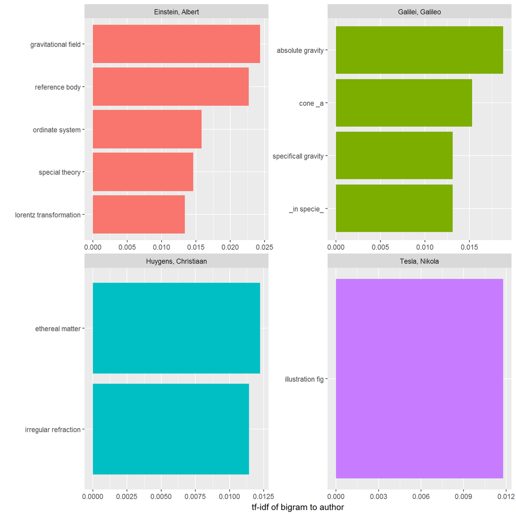

The units that distinguish each scientist could be passed to a classifier.

There are advantages and disadvantages to examining the tf-idf of bigrams rather than individual words. Pairs of consecutive words might capture structure that isn’t present when one is just counting single words, and may provide context that makes tokens more understandable. However, the per-bigram counts are also *sparser*: a typical two-word pair is rarer than either of its component words. Thus, bigrams can be especially useful when you have a very large text dataset.

## Sentiment Analysis

When human readers approach a text, we use our understanding of the emotional intent of words to infer whether a section of text is positive or negative, or perhaps characterized by some other more nuanced emotion like surprise or disgust. We can use the tools of text mining to approach the emotional content of text programmatically.

One way to analyze the sentiment of a text is to consider the text as a combination of its individual words and the sentiment content of the whole text as the sum of the sentiment content of the individual words. This isn’t the only way to approach sentiment analysis, but it is an often-used approach, *and* an approach that naturally takes advantage of the tidy tool ecosystem.

### The `sentiments` dataset

As discussed above, there are a variety of methods and dictionaries that exist for evaluating the opinion or emotion in text. The tidytext package contains several sentiment lexicons in the `sentiments` dataset.

```r
library(tidytext)

sentiments
```

```
## # A tibble: 27,314 x 4
##    word        sentiment lexicon score
##    <chr>       <chr>     <chr>   <int>
##  1 abacus      trust     nrc        NA
##  2 abandon     fear      nrc        NA
##  3 abandon     negative  nrc        NA
##  4 abandon     sadness   nrc        NA
##  5 abandoned   anger     nrc        NA
##  6 abandoned   fear      nrc        NA
##  7 abandoned   negative  nrc        NA
##  8 abandoned   sadness   nrc        NA
##  9 abandonment anger     nrc        NA
## 10 abandonment fear      nrc        NA
## # ... with 27,304 more rows
```

The three general-purpose lexicons are

- `AFINN` from [Finn Ãrup Nielsen](http://www2.imm.dtu.dk/pubdb/views/publication_details.php?id=6010),
- `bing` from [Bing Liu and collaborators](https://www.cs.uic.edu/~liub/FBS/sentiment-analysis.html), and
- `nrc` from [Saif Mohammad and Peter Turney](http://saifmohammad.com/WebPages/NRC-Emotion-Lexicon.htm).

All three of these lexicons are based on unigrams, i.e., single words. These lexicons contain many English words and the words are assigned scores for positive/negative sentiment, and also possibly emotions like joy, anger, sadness, and so forth. The `nrc` lexicon categorizes words in a binary fashion (“yes”/“no”) into categories of positive, negative, anger, anticipation, disgust, fear, joy, sadness, surprise, and trust. The `bing` lexicon categorizes words in a binary fashion into positive and negative categories. The `AFINN` lexicon assigns words with a score that runs between -5 and 5, with negative scores indicating negative sentiment and positive scores indicating positive sentiment. All of this information is tabulated in the `sentiments` dataset, and tidytext provides a function `get_sentiments()` to get specific sentiment lexicons without the columns that are not used in that lexicon.

```r
get_sentiments("afinn")
```

```
## # A tibble: 2,476 x 2
##    word       score
##    <chr>      <int>
##  1 abandon       -2
##  2 abandoned     -2
##  3 abandons      -2
##  4 abducted      -2
##  5 abduction     -2
##  6 abductions    -2
##  7 abhor         -3
##  8 abhorred      -3
##  9 abhorrent     -3
## 10 abhors        -3
## # ... with 2,466 more rows
```

```r
get_sentiments("bing")
```

```
## # A tibble: 6,788 x 2
##    word        sentiment
##    <chr>       <chr>
##  1 2-faced     negative
##  2 2-faces     negative
##  3 a+          positive
##  4 abnormal    negative
##  5 abolish     negative
##  6 abominable  negative
##  7 abominably  negative
##  8 abominate   negative
##  9 abomination negative
## 10 abort       negative
## # ... with 6,778 more rows
```

```r
get_sentiments("nrc")
```

```
## # A tibble: 13,901 x 2
##    word        sentiment
##    <chr>       <chr>
##  1 abacus      trust
##  2 abandon     fear
##  3 abandon     negative
##  4 abandon     sadness
##  5 abandoned   anger
##  6 abandoned   fear
##  7 abandoned   negative
##  8 abandoned   sadness
##  9 abandonment anger
## 10 abandonment fear
## # ... with 13,891 more rows
```

### Sentiment analysis with inner join

With data in a tidy format, sentiment analysis can be done as an inner join. This is another of the great successes of viewing text mining as a tidy data analysis task; much as removing stop words is an antijoin operation, performing sentiment analysis is an inner join operation.

```r
load("data/bronte.rda")
table(bronte$gutenberg_id)
```

```
##
##   767   768   969  1260  9182
##  6828 12085 18084 20659 21312
```

```r
bronte$linenumber = c(1:6828, 1:12085, 1:18084, 1:20659, 1:21312)

tidy_bronte <- bronte %>%
  unnest_tokens(word, text)
```

Notice that we chose the name `word` for the output column from `unnest_tokens()`. This is a convenient choice because the sentiment lexicons and stop word datasets have columns named `word`; performing inner joins and anti-joins is thus easier.

```r
nrcjoy <- get_sentiments("nrc") %>%
  filter(sentiment == "joy")

tidy_bronte %>%
  inner_join(nrcjoy) %>%
  count(word, sort = TRUE)
```

```
## # A tibble: 564 x 2
##    word        n
##    <chr>   <int>
##  1 good     1018
##  2 love      566
##  3 young     463
##  4 mother    417
##  5 found     405
##  6 child     339
##  7 hope      333
##  8 god       308
##  9 kind      308
## 10 present   306
## # ... with 554 more rows
```

We see many positive, happy words about hope, friendship, and love here.

Or instead we could examine how sentiment changes throughout each novel. We can do this with just a handful of lines that are mostly dplyr functions. First, we find a sentiment score for each word using the Bing lexicon and `inner_join()`.

Next, we count up how many positive and negative words there are in defined sections of each book. We define an `index` here to keep track of where we are in the narrative; this index (using integer division) counts up sections of 100 lines of text.

The `%/%` operator does integer division (`x %/% y` is equivalent to `floor(x/y)`) so the index keeps track of which 100-line section of text we are counting up negative and positive sentiment in.

Small sections of text may not have enough words in them to get a good estimate of sentiment while really large sections can wash out narrative structure. For these books, using 100 lines works well, but this can vary depending on individual texts, how long the lines were to start with, etc. We then use `spread()` so that we have negative and positive sentiment in separate columns, and lastly calculate a net sentiment (positive - negative).

```r
library(tidyr)

#tidy_bronte = arrange(tidy_bronte, )

brontesentiment <- tidy_bronte %>%
  inner_join(get_sentiments("bing")) %>%
  count(gutenberg_id, index = linenumber %/% 100, sentiment) %>%
  spread(sentiment, n, fill = 0) %>%
  mutate(sentiment = positive - negative)
```

Now we can plot these sentiment scores across the plot trajectory of each novel. Notice that we are plotting against the `index` on the x-axis that keeps track of narrative time in sections of text.

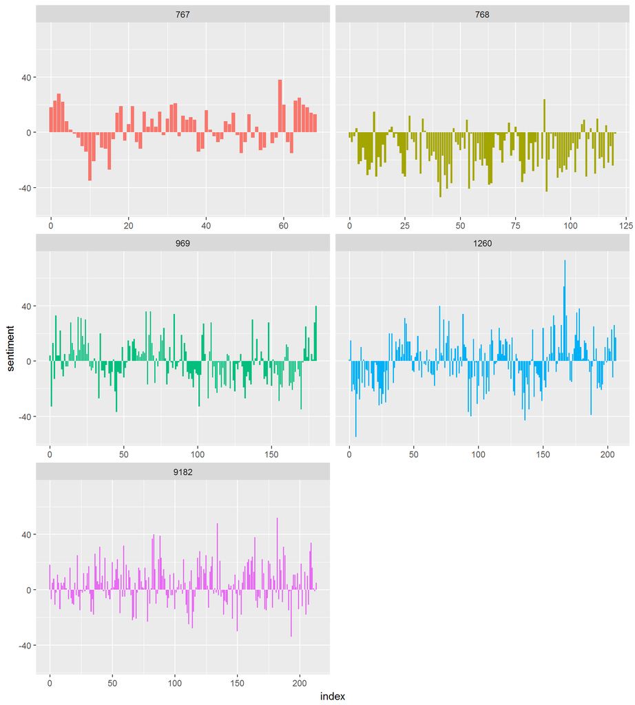

Sentiment through the narratives of Bronte’s novels

```r
brontesentiment$gutenberg_id=factor(brontesentiment$gutenberg_id)
ggplot(brontesentiment, aes(index, sentiment, fill = gutenberg_id)) +
  geom_col(show.legend = FALSE) +
  facet_wrap(~gutenberg_id, ncol = 2, scales = "free_x")
```

We can see in this Figure how the plot of each novel changes toward more positive or negative sentiment over the trajectory of the story.

```r
distinct(bronte, gutenberg_id) %>%
  inner_join(gutenberg_metadata)  %>% select(gutenberg_id, title)
```

```
## # A tibble: 5 x 2
##   gutenberg_id title
##          <int> <chr>
## 1          767 Agnes Grey
## 2          768 Wuthering Heights
## 3          969 The Tenant of Wildfell Hall
## 4         1260 Jane Eyre: An Autobiography
## 5         9182 Villette
```

### Using bigrams to provide context in sentiment analysis

This sentiment analysis approch simply counts the appearance of positive or negative words, according to a reference lexicon. One of the problems with this approach is that a word’s context can matter nearly as much as its presence. For example, the words “happy” and “like” will be counted as positive, even in a sentence like “I’m not **happy** and I don’t **like** it!”

Now that we have the data organized into bigrams, it’s easy to tell how often words are preceded by a word like “not”:

```r
bronte_bigrams <- bronte %>%
  unnest_tokens(bigram, text, token = "ngrams", n = 2)

bigrams_separated <- bronte_bigrams %>%
  separate(bigram, c("word1", "word2"), sep = " ")
```

```r
bigrams_separated %>%
  filter(word1 == "not") %>%
  count(word1, word2, sort = TRUE)
```

```
## # A tibble: 1,388 x 3
##    word1 word2     n
##    <chr> <chr> <int>
##  1 not   be      244
##  2 not   to      241
##  3 not   a       218
##  4 not   the     122
##  5 not   have    111
##  6 not   so       99
##  7 not   i        83
##  8 not   in       81
##  9 not   been     77
## 10 not   know     72
## # ... with 1,378 more rows
```

By performing sentiment analysis on the bigram data, we can examine how often sentiment-associated words are preceded by “not” or other negating words. We could use this to ignore or even reverse their contribution to the sentiment score.

Let’s use the AFINN lexicon for sentiment analysis, which you may recall gives a numeric sentiment score for each word, with positive or negative numbers indicating the direction of the sentiment.

```r
AFINN <- get_sentiments("afinn")

AFINN
```

```
## # A tibble: 2,476 x 2
##    word       score
##    <chr>      <int>
##  1 abandon       -2
##  2 abandoned     -2
##  3 abandons      -2
##  4 abducted      -2
##  5 abduction     -2
##  6 abductions    -2
##  7 abhor         -3
##  8 abhorred      -3
##  9 abhorrent     -3
## 10 abhors        -3
## # ... with 2,466 more rows
```

We can then examine the most frequent words that were preceded by “not” and were associated with a sentiment.

```r
not_words <- bigrams_separated %>%
  filter(word1 == "not") %>%
  inner_join(AFINN, by = c(word2 = "word")) %>%
  count(word2, score, sort = TRUE) %>%
  ungroup()

not_words
```

```
## # A tibble: 278 x 3
##    word2   score     n
##    <chr>   <int> <int>
##  1 like        2    66
##  2 help        2    43
##  3 leave      -1    30
##  4 care        2    22
##  5 love        3    21
##  6 forget     -1    19
##  7 want        1    17
##  8 wish        1    17
##  9 fit         1    15
## 10 trouble    -2    15
## # ... with 268 more rows
```

For example, the most common sentiment-associated word to follow “not” was “like”, which would normally have a (positive) score of 2.

It’s worth asking which words contributed the most in the “wrong” direction. To compute that, we can multiply their score by the number of times they appear (so that a word with a score of +3 occurring 10 times has as much impact as a word with a sentiment score of +1 occurring 30 times). We visualize the result with a bar plot (Figure @ref(fig:notwordsplot)).

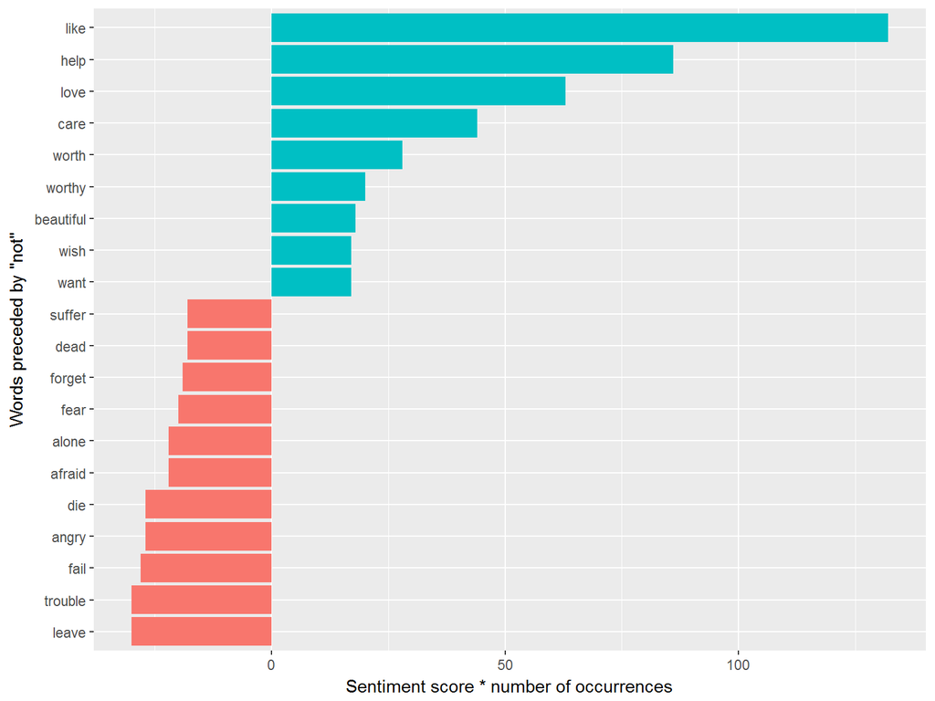

The 20 words followed by ‘not’ that had the greatest contribution to sentiment scores, in either a positive or negative direction

```r
#library(ggplot2)

not_words %>%
  mutate(contribution = n * score) %>%
  arrange(desc(abs(contribution))) %>%
  head(20) %>%
  mutate(word2 = reorder(word2, contribution)) %>%
  ggplot(aes(word2, n * score, fill = n * score > 0)) +
  geom_col(show.legend = FALSE) +
  xlab("Words preceded by \"not\"") +
  ylab("Sentiment score * number of occurrences") +
  coord_flip()
```

The bigrams “not like” and “not help” were overwhelmingly the largest causes of misidentification, making the text seem much more positive than it is. But we can see phrases like “not afraid” and “not fail” sometimes suggest text is more negative than it is.

“Not” isn’t the only term that provides some context for the following word. We could pick four common words (or more) that negate the subsequent term, and use the same joining and counting approach to examine all of them at once.

```r
negation_words <- c("not", "no", "never", "without")

negated_words <- bigrams_separated %>%
  filter(word1 %in% negation_words) %>%
  inner_join(AFINN, by = c(word2 = "word")) %>%
  count(word1, word2, score, sort = TRUE) %>%
  ungroup()
```

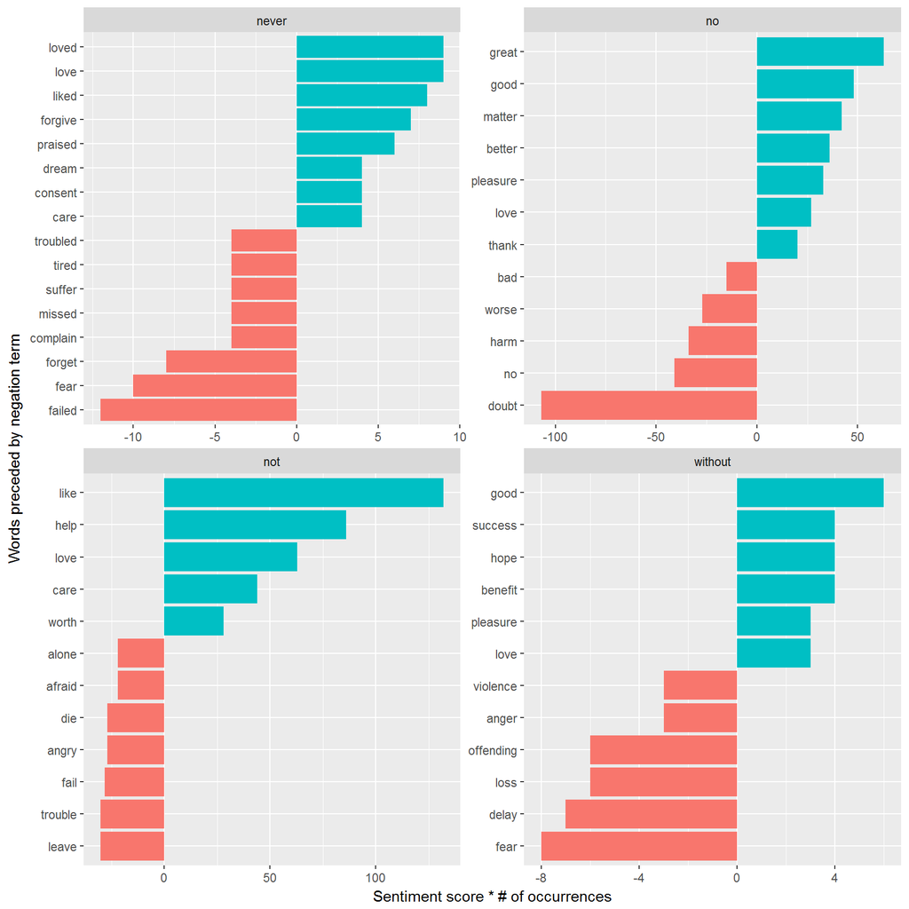

The most common positive or negative words to follow negations such as ‘never’, ‘no’, ‘not’, and ‘without’